# Motivation for Log Transform Function

Tuesday, January 13, 2015

## Common statistical Problem:

Your data is non-normal, and you need to make it normal for statistical analysis. Often, people turn to log-transform.

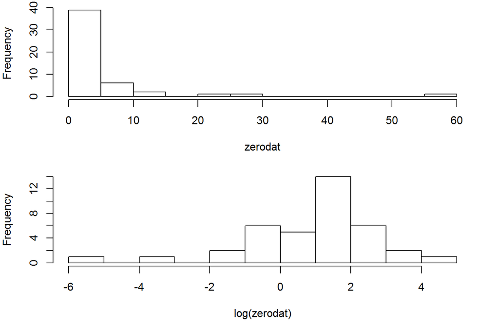

## But:

your data has some zeros, which are undefined after a log tranform:

```
data logdata
 [1,] 0.0000    -Inf
 [2,] 0.0000    -Inf
 [3,] 0.0000    -Inf
 [4,] 0.0000    -Inf
 [5,] 0.0000    -Inf
 [6,] 0.0000    -Inf
 [7,] 0.0000    -Inf
 [8,] 0.0000    -Inf
 [9,] 0.0000    -Inf
[10,] 0.0000    -Inf
[11,] 0.0000    -Inf
[12,] 0.0000    -Inf
[13,] 0.0029 -5.8430
[14,] 0.0419 -3.1725
[15,] 0.1719 -1.7608
[16,] 0.1868 -1.6777
[17,] 0.4309 -0.8419
[18,] 0.4459 -0.8077
[19,] 0.4809 -0.7321
[20,] 0.8135 -0.2064
```

A common solution is to add one to the data.

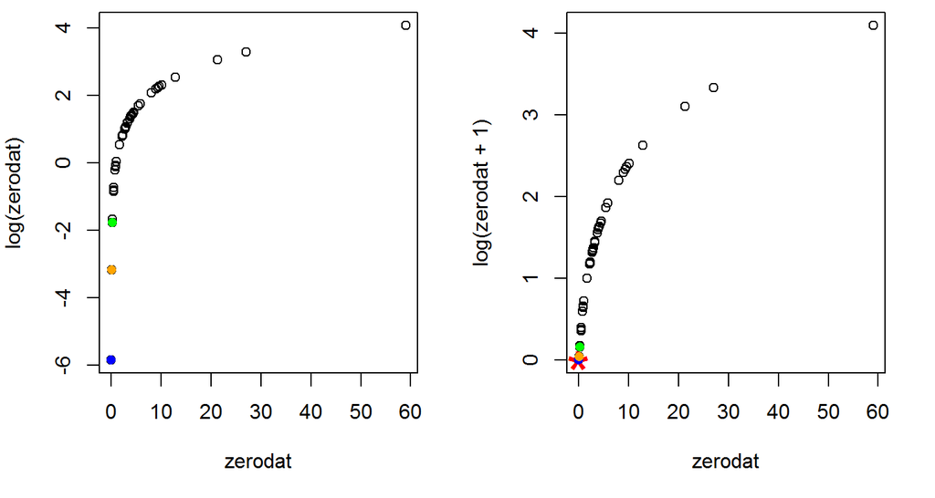

```
[1] 0.0000 0.0000 0.0000 0.0000 0.0000 0.0000 0.0000 0.0000 0.0000 0.0000
[11] 0.0000 0.0000 0.0029 0.0419 0.1719
```

Maybe adding 1 is too much in this case.

Perhaps something smaller? Try 0.01.

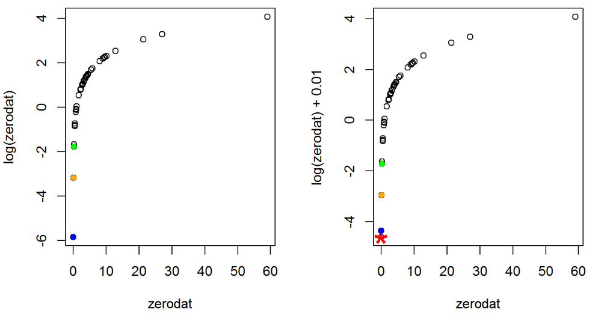

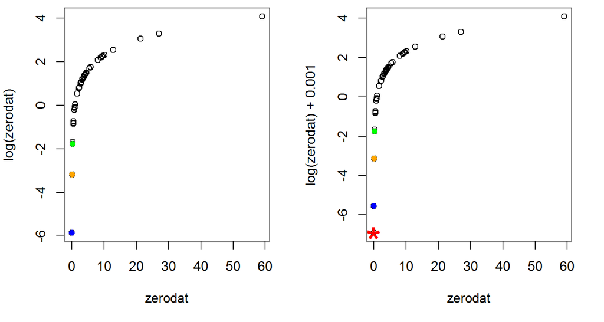

How to determine the correct small value to add?

McCune and Grace 2002 (Chapt 9) suggest this method to figured out a small value that

1. Preserves original orders of magnitude in the data
2. Results in values of zero when initial value is zero.

Given

- Min(x) is the smallest nonzero value in the data
- Int(x) is a function that truncates x to an integer by dropping digits after the decimal point
- c = order of magnitude constant = Int(log(Min(x))
- d = decimal constant = log-1 (c)

then the transformation is

**b = log(x + d) - c**

In this case,

c= -6

d= 0.0025

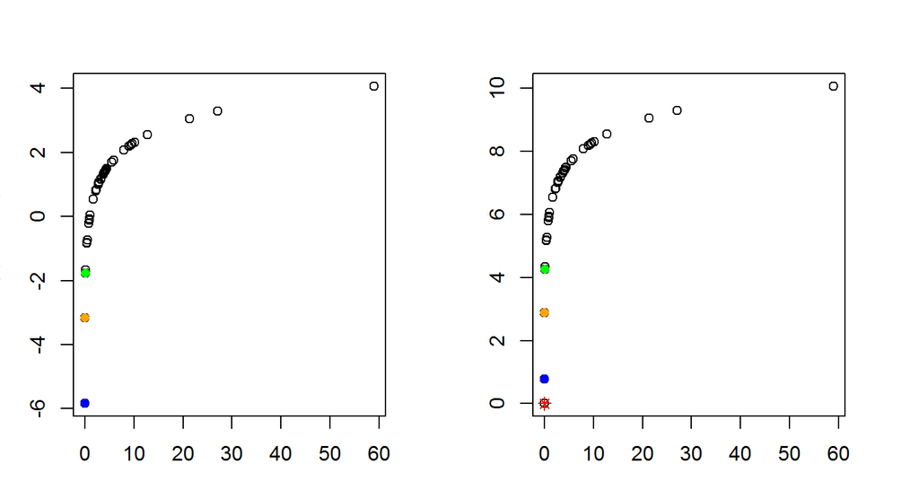